# SR_04_RLTD_ORG_CORP_CTRL_NA

Direct controlling entity - not applicable · Text report

## Overview

**Description**

Direct Controlling Entity - Literal N/A

**Table**

`SR-P04-T01-ID-RLTD-ORGS-TAXABLE-CORPORATION` (many)

**Location code**

`SCHED-R-PART-04-COL-D`

**Family**

`SCHED-R-PART-04-COL-D` · siblings: SR_04_RLTD_ORG_CORP_CTRL_NAME_L1, SR_04_RLTD_ORG_CORP_CTRL_NAME_L2

**Data type**

text (xsd: , StringType)

**Scope**

PC

**Status**

unreviewed

3

xpaths mapped (2 observed)

107,663

filings with a value

2009–2024

tax years observed

2

open flags (1 errors)

## Flags

| Severity | Flag | Xpath | Detail |
| --- | --- | --- | --- |
| ⚠ error | `POLARITY` | IRS990ScheduleR/Form990ScheduleRPartIV/DirectControllingEntity/NotApplicable | negated element ‘NotApplicable’ pooled with non-negated xpaths |
| ⓘ info | `UNOBSERVED` | IRS990ScheduleR/Form990ScheduleRPartIV/DirectControllingEntity/NotApplicable | never observed in TY2009-2024 filings |

## Xpaths

All mapped xpaths (under /Return/ReturnData or /Return/ReturnHeader), oldest first. Charts label each series by its xpath.

| Xpath | Form | Chart label | First year | Last year | Versions | Filings | Repeats in |
| --- | --- | --- | --- | --- | --- | --- | --- |
| IRS990ScheduleR/Form990ScheduleRPartIV/DirectControllingEntityNA | Sched R | …cheduleR/Form990ScheduleRPartIV/DirectControllingEntityNA | 2009 | 2012 | 16 | 18,679 | 52.7% |
| IRS990ScheduleR/IdRelatedOrgTxblCorpTrGrp/DirectControllingNACd | Sched R | …ScheduleR/IdRelatedOrgTxblCorpTrGrp/DirectControllingNACd | 2013 | 2024 | 37 | 88,984 | 53.9% |
| IRS990ScheduleR/Form990ScheduleRPartIV/DirectControllingEntity/NotApplicable | Sched R | …m990ScheduleRPartIV/DirectControllingEntity/NotApplicable |  |  |  | 0 |  |

## Coverage

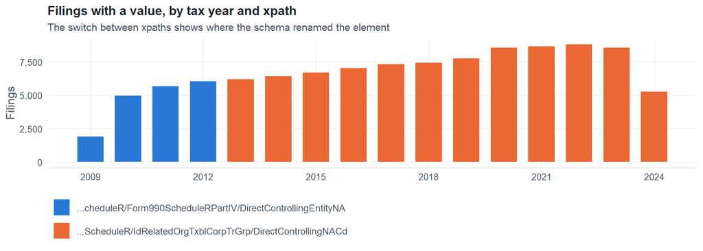

**Table view**

Table view: filings by tax year and series

| Tax year | …cheduleR/Form990ScheduleRPartIV/DirectControllingEntityNA | …ScheduleR/IdRelatedOrgTxblCorpTrGrp/DirectControllingNACd |
| --- | --- | --- |
| 2009 | 1,920 | 0 |
| 2010 | 4,987 | 0 |
| 2011 | 5,703 | 0 |
| 2012 | 6,069 | 0 |
| 2013 | 0 | 6,226 |
| 2014 | 0 | 6,444 |
| 2015 | 0 | 6,734 |
| 2016 | 0 | 7,054 |
| 2017 | 0 | 7,352 |
| 2018 | 0 | 7,451 |
| 2019 | 0 | 7,774 |
| 2020 | 0 | 8,581 |
| 2021 | 0 | 8,682 |
| 2022 | 0 | 8,824 |
| 2023 | 0 | 8,581 |
| 2024 | 0 | 5,281 |

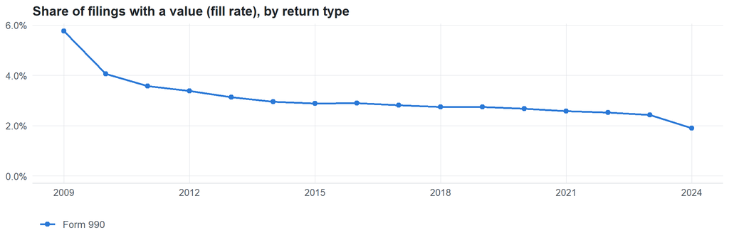

**Table view**

Table view: fill rate

| Tax year | Return type | Filings | All filings | Fill rate |
| --- | --- | --- | --- | --- |
| 2009 | Form 990 | 1,920 | 33,311 | 5.76% |
| 2010 | Form 990 | 4,987 | 123,025 | 4.05% |
| 2011 | Form 990 | 5,703 | 159,504 | 3.58% |
| 2012 | Form 990 | 6,069 | 179,688 | 3.38% |
| 2013 | Form 990 | 6,226 | 198,855 | 3.13% |
| 2014 | Form 990 | 6,444 | 218,619 | 2.95% |
| 2015 | Form 990 | 6,734 | 233,519 | 2.88% |
| 2016 | Form 990 | 7,054 | 243,903 | 2.89% |
| 2017 | Form 990 | 7,352 | 261,612 | 2.81% |
| 2018 | Form 990 | 7,451 | 271,442 | 2.74% |
| 2019 | Form 990 | 7,774 | 283,694 | 2.74% |
| 2020 | Form 990 | 8,581 | 320,342 | 2.68% |
| 2021 | Form 990 | 8,682 | 336,480 | 2.58% |
| 2022 | Form 990 | 8,824 | 349,055 | 2.53% |
| 2023 | Form 990 | 8,581 | 354,768 | 2.42% |
| 2024 | Form 990 | 5,281 | 277,298 | 1.90% |

## Repeating groups

Table cardinality in the concordance: **many**. 2 of 2 observed xpaths repeat within a filing.

Repeating element each xpath was observed in (from the raw indexed xpath)

| Xpath | Repeating element | Filings (summed over years) |
| --- | --- | --- |
| IRS990ScheduleR/Form990ScheduleRPartIV/DirectControllingEntityNA | (none) | 8022 |
| IRS990ScheduleR/Form990ScheduleRPartIV/DirectControllingEntityNA | IRS990ScheduleR/Form990ScheduleRPartIV | 10657 |
| IRS990ScheduleR/IdRelatedOrgTxblCorpTrGrp/DirectControllingNACd | (none) | 37301 |
| IRS990ScheduleR/IdRelatedOrgTxblCorpTrGrp/DirectControllingNACd | IRS990ScheduleR/IdRelatedOrgTxblCorpTrGrp | 51683 |

## Values

| Result | Check | Detail |
| --- | --- | --- |
| ✓ pass | Values are text, not numbers | 0% of values are numeric |
| ✓ pass | No sign of truncation | longest values do not sit at a common field limit |
| ⓘ info | No dominant boilerplate value | most common value covers 100% of filings: “N/A” |

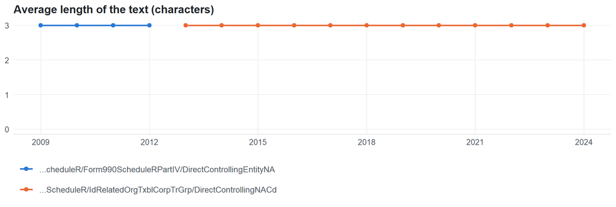

**Table view**

Table view: length and variety by tax year

| Series | Tax year | Filings | Avg length | Max length | Distinct values (approx.) |
| --- | --- | --- | --- | --- | --- |
| …cheduleR/Form990ScheduleRPartIV/DirectControllingEntityNA | 2009 | 1,920 | 3 | 3 | 1 |
| …cheduleR/Form990ScheduleRPartIV/DirectControllingEntityNA | 2010 | 4,987 | 3 | 3 | 1 |
| …cheduleR/Form990ScheduleRPartIV/DirectControllingEntityNA | 2011 | 5,703 | 3 | 3 | 1 |
| …cheduleR/Form990ScheduleRPartIV/DirectControllingEntityNA | 2012 | 6,069 | 3 | 3 | 1 |
| …ScheduleR/IdRelatedOrgTxblCorpTrGrp/DirectControllingNACd | 2013 | 6,226 | 3 | 3 | 1 |
| …ScheduleR/IdRelatedOrgTxblCorpTrGrp/DirectControllingNACd | 2014 | 6,444 | 3 | 3 | 1 |
| …ScheduleR/IdRelatedOrgTxblCorpTrGrp/DirectControllingNACd | 2015 | 6,734 | 3 | 3 | 1 |
| …ScheduleR/IdRelatedOrgTxblCorpTrGrp/DirectControllingNACd | 2016 | 7,054 | 3 | 3 | 1 |
| …ScheduleR/IdRelatedOrgTxblCorpTrGrp/DirectControllingNACd | 2017 | 7,352 | 3 | 3 | 1 |
| …ScheduleR/IdRelatedOrgTxblCorpTrGrp/DirectControllingNACd | 2018 | 7,451 | 3 | 3 | 1 |
| …ScheduleR/IdRelatedOrgTxblCorpTrGrp/DirectControllingNACd | 2019 | 7,774 | 3 | 3 | 1 |
| …ScheduleR/IdRelatedOrgTxblCorpTrGrp/DirectControllingNACd | 2020 | 8,581 | 3 | 3 | 1 |
| …ScheduleR/IdRelatedOrgTxblCorpTrGrp/DirectControllingNACd | 2021 | 8,682 | 3 | 3 | 1 |
| …ScheduleR/IdRelatedOrgTxblCorpTrGrp/DirectControllingNACd | 2022 | 8,824 | 3 | 3 | 1 |
| …ScheduleR/IdRelatedOrgTxblCorpTrGrp/DirectControllingNACd | 2023 | 8,581 | 3 | 3 | 1 |
| …ScheduleR/IdRelatedOrgTxblCorpTrGrp/DirectControllingNACd | 2024 | 5,281 | 3 | 3 | 1 |

Most common values by xpath (all years; long values truncated)

| Series | Value | Filings | Share |
| --- | --- | --- | --- |
| …cheduleR/Form990ScheduleRPartIV/DirectControllingEntityNA | N/A | 18,679 | 100.0% |
| …ScheduleR/IdRelatedOrgTxblCorpTrGrp/DirectControllingNACd | N/A | 88,984 | 100.0% |

## Examples

| Tax year | Return | Xpath | Organization | Value | Source |
| --- | --- | --- | --- | --- | --- |
| 2024 | 990 | IRS990ScheduleR/IdRelatedOrgTxblCorpTrGrp/DirectControllingNACd | RISEWELL COMMUNITY SERVICES INC FKA | N/A | [XML](https://gt990datalake-rawdata.s3.amazonaws.com/EfileData/XmlFiles/202610589349301811_public.xml) |
| 2023 | 990 | IRS990ScheduleR/IdRelatedOrgTxblCorpTrGrp/DirectControllingNACd | MERIT CLUB | N/A | [XML](https://gt990datalake-rawdata.s3.amazonaws.com/EfileData/XmlFiles/202443209349302659_public.xml) |
| 2022 | 990 | IRS990ScheduleR/IdRelatedOrgTxblCorpTrGrp/DirectControllingNACd | Scott & White Healthcare | N/A | [XML](https://gt990datalake-rawdata.s3.amazonaws.com/EfileData/XmlFiles/202441349349302274_public.xml) |
| 2021 | 990 | IRS990ScheduleR/IdRelatedOrgTxblCorpTrGrp/DirectControllingNACd | COMMUNITY HOSPITAL OF ANDERSON AND | N/A | [XML](https://gt990datalake-rawdata.s3.amazonaws.com/EfileData/XmlFiles/202203149349305235_public.xml) |
| 2020 | 990 | IRS990ScheduleR/IdRelatedOrgTxblCorpTrGrp/DirectControllingNACd | SMYRNA RHF HOUSING INC | N/A | [XML](https://gt990datalake-rawdata.s3.amazonaws.com/EfileData/XmlFiles/202240179349300204_public.xml) |
| 2019 | 990 | IRS990ScheduleR/IdRelatedOrgTxblCorpTrGrp/DirectControllingNACd | ALEXANDRIA SENIOR HOUSING INC | N/A | [XML](https://gt990datalake-rawdata.s3.amazonaws.com/EfileData/XmlFiles/202033189349302573_public.xml) |
| 2018 | 990 | IRS990ScheduleR/IdRelatedOrgTxblCorpTrGrp/DirectControllingNACd | RAPID CITY GOOD SAMARITAN HOUSING GP | N/A | [XML](https://gt990datalake-rawdata.s3.amazonaws.com/EfileData/XmlFiles/201902889349301005_public.xml) |
| 2017 | 990 | IRS990ScheduleR/IdRelatedOrgTxblCorpTrGrp/DirectControllingNACd | TELACU SENIOR COURT INC | N/A | [XML](https://gt990datalake-rawdata.s3.amazonaws.com/EfileData/XmlFiles/201832849349301128_public.xml) |
| 2016 | 990 | IRS990ScheduleR/IdRelatedOrgTxblCorpTrGrp/DirectControllingNACd | Bellin Psychiatric Center | N/A | [XML](https://gt990datalake-rawdata.s3.amazonaws.com/EfileData/XmlFiles/201812279349301906_public.xml) |
| 2015 | 990 | IRS990ScheduleR/IdRelatedOrgTxblCorpTrGrp/DirectControllingNACd | OUR YOUTH INC | N/A | [XML](https://gt990datalake-rawdata.s3.amazonaws.com/EfileData/XmlFiles/201622219349301232_public.xml) |
| 2014 | 990 | IRS990ScheduleR/IdRelatedOrgTxblCorpTrGrp/DirectControllingNACd | BRIDGE HOUSING CORPORATION - SOUTHERN CALIFORNIA | N/A | [XML](https://gt990datalake-rawdata.s3.amazonaws.com/EfileData/XmlFiles/201503179349309785_public.xml) |
| 2013 | 990 | IRS990ScheduleR/IdRelatedOrgTxblCorpTrGrp/DirectControllingNACd | Alexian Brothers Behavioral Health Hospital | N/A | [XML](https://gt990datalake-rawdata.s3.amazonaws.com/EfileData/XmlFiles/201501279349301430_public.xml) |

## Reviewer checklist

- The definition matches the form line and instructions for every xpath’s schema years.
- Every xpath pooled here measures the same thing on the 990 and 990-EZ (close enough for analysis).
- The coverage chart has no unexplained gaps or jumps between tax years.
- Each open flag is fixed, or accepted with a note in validation_log.csv.
- Values answer the question on the form line (not another line’s explanation).
- Boilerplate such as ‘See Schedule O’ or ‘N/A’ is expected here, or should be treated as missing.
- Text that is really a number or a code is flagged for a different data type.

Record the review as a row in `inst/extdata/src/validation_log.csv` (variable_name, reviewer, date, status, note). Evidence built 2026-09-23 17:09:04 MST from the ef2 DuckDB builds (tax years 2009–2024).